# Lista 1 - Planejamento e Análise de Experimentos

Bruno Mesquita dos Santo

2024-02-26

#### 3) O conjunto de dados seguintes é proveniente de um experimento conduzido para caracterização de quatro variedades de pêra (A, B, C e D) com relação ao peso por fruto, medido em gramas. Foi colhida uma amostra aleatória de cinco frutos para cada variedade. Os valores obtidos foram:

> Repetições = 5 Tratamentos = 4

```r
tratA <- c(78, 88, 72, 74, 98)
tratB <- c(79, 56, 71, 96, 55)
tratC <- c(63, 68, 58, 79, 59)
tratD <- c(60, 65, 59, 54, 58)
X <-c(tratA,tratB, tratC, tratD)
Y <- rep(c("A", "B", "C","D"), each = 5)
dados <- data.frame(Resp=X,Trat=Y)
dados
```

| Resp | Trat |
| --- | --- |
| 78 | A |
| 88 | A |
| 72 | A |
| 74 | A |
| 98 | A |
| 79 | B |
| 56 | B |
| 71 | B |
| 96 | B |
| 55 | B |

[output cut: 10 more lines]

##### a) Testar a homogeneidade de variâncias utilizando o Teste de Hartley.

```r
var(tratA)
```

```
## [1] 118
```

```r
var(tratB)
```

```
## [1] 292.3
```

```r
var(tratC)
```

```
## [1] 73.3
```

```r
var(tratD)
```

```
## [1] 15.7
```

Hcal = S²max/S²min

```r
Hcal <- 292.3/15.7
Hcal
```

```
## [1] 18.61783
```

Htab há 4 tratamento e (5-1)repetições por tratamento, a 5% de significância

```r
qmaxFratio(0.95,4,4)
```

```
## [1] 20.55922
```

Como Hc<Htab, rejeita-se a hipotese de heterogeneidade de variância dos grupos

##### b) Se o teste na letra a) não for significativo então obtenha a tabela de analise

de variância, aplique o teste F e comente o resultado.

```r
modelo <- aov(Resp~Trat, data = dados)
anova(modelo)
```

|  | Df | Sum Sq | Mean Sq | F value | Pr(>F) |
| --- | --- | --- | --- | --- | --- |
| Trat | 3 | 1413.8 | 471.2667 | 3.775419 | 0.03188102 |
| Residuals | 16 | 1997.2 | 124.8250 | NA | NA |

Hipótese:

$$\left\{ \begin{array}{rc}
H0: \beta1 = \beta2 = \beta3 = \beta4 = 0 \\
H1: pelo \ menos \ um \ \beta \ difere \ de \ zero \\
\end{array}\right.$$

Dado que nosso modelo possuí p-value: < 0.03188, podemos concluir que há 5% nível de significância ele rejeita H0, logo o modelo é significativo.

##### c) Aplique os testes: Teste t de Student, Teste de Tukey, Teste de Duncan, Teste de S-N-K, Teste de Dunnett (considerando o tratamento controle sendo A) e o Teste de Scheffé.

Teste t de Student:

$$\left\{ \begin{array}{rc}
H0: Y = 0 \\
H1: Y \neq 0
\end{array}\right.$$

```r
t.test(tratA,tratB)
```

```
##
##  Welch Two Sample t-test
##
## data:  tratA and tratB
## t = 1.1701, df = 6.777, p-value = 0.2814
## alternative hypothesis: true difference in means is not equal to 0
## 95 percent confidence interval:
##  -10.96414  32.16414
## sample estimates:
## mean of x mean of y
##      82.0      71.4
```

Aceita h0, logo a diferença das médias não é estatisticamente significativa.

```r
t.test(tratA,tratC)
```

```
##
##  Welch Two Sample t-test
##
## data:  tratA and tratC
## t = 2.6837, df = 7.5858, p-value = 0.02913
## alternative hypothesis: true difference in means is not equal to 0
## 95 percent confidence interval:
##   2.199586 31.000414
## sample estimates:
## mean of x mean of y
##      82.0      65.4
```

Rejeita h0, logo a diferença das médias é estatisticamente significativa.

```r
t.test(tratA,tratD)
```

```
##
##  Welch Two Sample t-test
##
## data:  tratA and tratD
## t = 4.4091, df = 5.0459, p-value = 0.006815
## alternative hypothesis: true difference in means is not equal to 0
## 95 percent confidence interval:
##   9.543613 36.056387
## sample estimates:
## mean of x mean of y
##      82.0      59.2
```

Rejeita h0, logo a diferença das médias é estatisticamente significativa.

```r
t.test(tratB,tratC)
```

```
##
##  Welch Two Sample t-test
##
## data:  tratB and tratC
## t = 0.70167, df = 5.8875, p-value = 0.5097
## alternative hypothesis: true difference in means is not equal to 0
## 95 percent confidence interval:
##  -15.02093  27.02093
## sample estimates:
## mean of x mean of y
##      71.4      65.4
```

Aceita h0, logo a diferença das médias não é estatisticamente significativa.

```r
t.test(tratB,tratD)
```

```
##
##  Welch Two Sample t-test
##
## data:  tratB and tratD
## t = 1.5544, df = 4.4285, p-value = 0.1882
## alternative hypothesis: true difference in means is not equal to 0
## 95 percent confidence interval:
##  -8.784296 33.184296
## sample estimates:
## mean of x mean of y
##      71.4      59.2
```

Aceita h0, logo a diferença das médias não é estatisticamente significativa.

```r
t.test(tratC,tratD)
```

```
##
##  Welch Two Sample t-test
##
## data:  tratC and tratD
## t = 1.4695, df = 5.6383, p-value = 0.1952
## alternative hypothesis: true difference in means is not equal to 0
## 95 percent confidence interval:
##  -4.28619 16.68619
## sample estimates:
## mean of x mean of y
##      65.4      59.2
```

Aceita h0, logo a diferença das médias não é estatisticamente significativa.

Utilizaremos o TratA por ter a maior média.

Teste de Tukey:

```r
TukeyHSD(modelo)
```

```
##   Tukey multiple comparisons of means
##     95% family-wise confidence level
##
## Fit: aov(formula = Resp ~ Trat, data = dados)
##
## $Trat
##      diff      lwr       upr     p adj
## B-A -10.6 -30.8163  9.616299 0.4602137
## C-A -16.6 -36.8163  3.616299 0.1281553
## D-A -22.8 -43.0163 -2.583701 0.0244592
## C-B  -6.0 -26.2163 14.216299 0.8303280
## D-B -12.2 -32.4163  8.016299 0.3429223
## D-C  -6.2 -26.4163 14.016299 0.8163995
```

```r
plot(TukeyHSD(modelo))
```

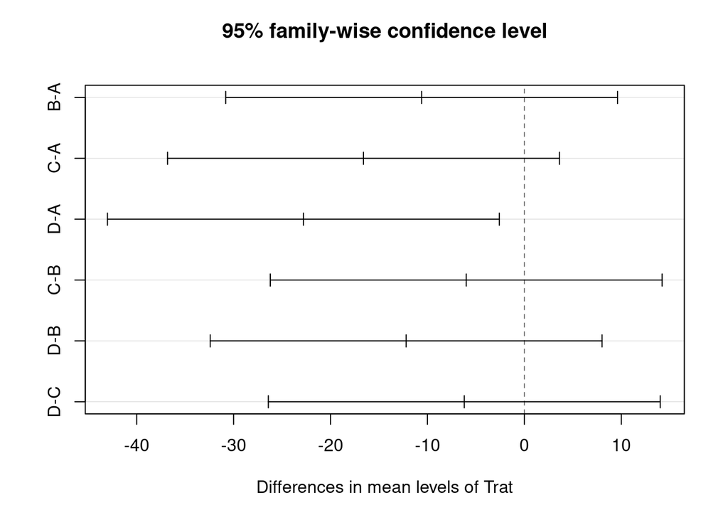

[figure not shown]

Somente D e A são diferentes entre si, como trat A tem maior média, ele será usado

Teste de Duncan:

```r
resultado_duncan <- duncan.test(modelo, "Trat")
print(resultado_duncan)
```

```
## $statistics
##   MSerror Df Mean       CV
##   124.825 16 69.5 16.07556
##
## $parameters
##     test name.t ntr alpha
##   Duncan   Trat   4  0.05
##
## $duncan
##      Table CriticalRange
## 2 2.997999      14.97950
## 3 3.143802      15.70801
## 4 3.234945      16.16340
##
## $means
##   Resp       std r       se Min Max Q25 Q50 Q75
## A 82.0 10.862780 5 4.996499  72  98  74  78  88
## B 71.4 17.096783 5 4.996499  55  96  56  71  79
## C 65.4  8.561542 5 4.996499  58  79  59  63  68
## D 59.2  3.962323 5 4.996499  54  65  58  59  60
##
## $comparison
## NULL
##
## $groups
##   Resp groups
## A 82.0      a
## B 71.4     ab
## C 65.4      b
## D 59.2      b
##
## attr(,"class")
## [1] "group"
```

Diferença apenas entre o TratA - TratC e TratA - TratD.

SNK

W1 = q(s/sqrt(r))

q = o valor na tabela de Tukey (nº de médias abrangidas pelo contraste, nº de g.l.Resíduo) s = sqrt(qmerro) r = numero de repetições

```r
q <- qtukey(0.95, 4, 16)
s <- sqrt(124.83)
r <- 5
print(q*(s/sqrt(r)))
```

```
## [1] 20.2167
```

```r
mean(tratA)-mean(tratD)
```

```
## [1] 22.8
```

```r
mean(tratA)-mean(tratC)
```

```
## [1] 16.6
```

Como Yestimado>(contraste de duas médias) então rejeita-se H0. logo MA != MD, mas H0 é aceito entre MA, MB e MC

DUNNET

```r
DunnettTest(list(tratA, tratB, tratC, tratD))
```

[output not shown]

A média do tratD é significativamente diferente da média tratA, mas as médias do TratB e C não diferem significativamente.

#### 4) Para avaliar a condição de fertilidade do solo de uma propriedade rural foram coletadas quatro amostras de cada um dos cinco tipos de solos. Os valores obtidos para o teor de carbono orgânico, em g.kg-1, em cada solo, foram:

```r
A <- c(22, 25, 23, 26)
B <- c( 24, 27, 25, 29)
C <- c( 20, 22, 23, 21)
D <- c( 26, 28, 30, 29)
E <- c(26, 23, 21, 23)

X<- c(A,B,C,D,E)
Y <- rep(c("A", "B", "C", "D", "E"), each = 4)
dados <- data.frame(Resp=X,Trat=Y)
dados
```

| Resp | Trat |
| --- | --- |
| 22 | A |
| 25 | A |
| 23 | A |
| 26 | A |
| 24 | B |
| 27 | B |
| 25 | B |
| 29 | B |
| 20 | C |
| 22 | C |

[output cut: 10 more lines]

```r
shapiro.test(dados$Resp)
```

```
##
##  Shapiro-Wilk normality test
##
## data:  dados$Resp
## W = 0.95566, p-value = 0.4612
```

pvalor maior que 0.05, dados estão normais(H0)

```r
bartlett.test(Resp~Trat, data=dados)
```

```
##
##  Bartlett test of homogeneity of variances
##
## data:  Resp by Trat
## Bartlett's K-squared = 0.84319, df = 4, p-value = 0.9326
```

pvalor maior que 0.05, dados tem homogeneidade(H0)

```r
modelo <- aov(Resp~Trat, data = dados)
anova(modelo)
```

|  | Df | Sum Sq | Mean Sq | F value | Pr(>F) |
| --- | --- | --- | --- | --- | --- |
| Trat | 4 | 111.30 | 27.825000 | 8.143902 | 0.001066941 |
| Residuals | 15 | 51.25 | 3.416667 | NA | NA |

> Fcalc<- 27.8250/3.4167 #8.143823 qf(0.95,4,15) #3.055568 Como Fcal>Ftab, rejeita-se H0, logo, pelo menos, um tratamento difere dos outros

#### 5) Um experimento foi conduzido para avaliar diferentes métodos de conservação das espiguetas de mini milho com a finalidade de proporcionar um produto com qualidade. Foi utilizado o delineamento inteiramente casualizado, com quatro repetições, sendo as parcelas constituídas por três embalagens, contendo cada uma, 15 espiguetas. A variável medida foi o teor de vitamina C. Os tratamentos e os valores de vitamina C, em mg/100g, obtidos foram:

```r
AD <- c(7, 9, 10, 9)
AA <- c(18, 20, 17, 17)
LC <- c(15, 14, 15, 13)
AAR <- c(9, 7, 10, 8)
LCR <- c(9, 8, 10, 10)
```

##### a) Elabore um conjunto de contrastes ortogonais úteis para o pesquisador:

Y = 4m1 - m2 - m3 - m4 - m5 h0 = y = 0 <=> m1 = (m2 + m3 + m4 + m5)/4

Y2 = m1 - m2 h0 = y2 = 0 <=> m1 = m2

##### b) Explique o significado de cada contraste:

O contraste Y verifica ser a media do tratamento 1 é igual a média dos tratamentos restantes. Já o Y2 verifica a igualdade da média de dois tratamentos.

##### c) Elabore a análise da variância, com interpretação dos resultados:

```r
X<- c(AD,AA,LC,AAR,LCR)
Y <- rep(c("A", "B", "C", "D", "E"), each = 4)
dados <- data.frame(Resp=X,Trat=Y)
dados
```

| Resp | Trat |
| --- | --- |
| 7 | A |
| 9 | A |
| 10 | A |
| 9 | A |
| 18 | B |
| 20 | B |
| 17 | B |
| 17 | B |
| 15 | C |
| 14 | C |

[output cut: 10 more lines]

```r
shapiro.test(dados$Resp)
```

```
##
##  Shapiro-Wilk normality test
##
## data:  dados$Resp
## W = 0.88768, p-value = 0.02438
```

pvalor menor que 0.05, dados não estão normais(H0)

```r
bartlett.test(Resp~Trat, data=dados)
```

```
##
##  Bartlett test of homogeneity of variances
##
## data:  Resp by Trat
## Bartlett's K-squared = 0.66719, df = 4, p-value = 0.9553
```

pvalor maior que 0.05, dados tem homogeneidade(H0)

```r
modelo <- aov(Resp~Trat, data = dados)
anova(modelo)
```

|  | Df | Sum Sq | Mean Sq | F value | Pr(>F) |
| --- | --- | --- | --- | --- | --- |
| Trat | 4 | 284.50 | 71.125000 | 50.20588 | 1.647699e-08 |
| Residuals | 15 | 21.25 | 1.416667 | NA | NA |

Hipótese:

$$\left\{ \begin{array}{rc}
H0: \beta1 = \beta2 = \beta3 = \beta4 = 0 \\
H1: pelo \ menos \ um \ \beta \ difere \ de \ zero \\
\end{array}\right.$$

Dado que nosso modelo possuí p-value: 1.648e-08 < 0.05, podemos concluir que há 5% nível de significância ele rejeita H0, logo o modelo é significativo.

##### d) Aplique o teste de Tukey (5%) e o teste SNK (5%). Comente os resultados.

Tukey:

```r
TukeyHSD(modelo)
```

```
##   Tukey multiple comparisons of means
##     95% family-wise confidence level
##
## Fit: aov(formula = Resp ~ Trat, data = dados)
##
## $Trat
##      diff        lwr       upr     p adj
## B-A  9.25   6.651124 11.848876 0.0000001
## C-A  5.50   2.901124  8.098876 0.0000799
## D-A -0.25  -2.848876  2.348876 0.9981018
## E-A  0.50  -2.098876  3.098876 0.9738847
## C-B -3.75  -6.348876 -1.151124 0.0036007
## D-B -9.50 -12.098876 -6.901124 0.0000001
## E-B -8.75 -11.348876 -6.151124 0.0000003
## D-C -5.75  -8.348876 -3.151124 0.0000483
## E-C -5.00  -7.598876 -2.401124 0.0002256
## E-D  0.75  -1.848876  3.348876 0.8957929
```

B-A, C-A, C-B, D-B, E-B, D-C, E-C são diferentes entre si/

SNK

W1 = q(s/sqrt(r))

q = o valor na tabela de Tukey (nº de médias abrangidas pelo contraste, nº de g.l.Resíduo) s = sqrt(qmerro) r = numero de repetições

```r
q <- qtukey(0.95, 5, 15)
s <- sqrt(1.417)
r <- 4
print(q*(s/sqrt(r)))
```

```
## [1] 2.599181
```

```r
mean(AD)
```

```
## [1] 8.75
```

```r
mean(AA)
```

```
## [1] 18
```

```r
mean(LC)
```

```
## [1] 14.25
```

```r
mean(AAR)
```

```
## [1] 8.5
```

```r
mean(LCR)
```

```
## [1] 9.25
```

```r
mean(LCR)-mean(AAR)
```

```
## [1] 0.75
```

```r
mean(LCR)-mean(AD)
```

```
## [1] 0.5
```

```r
mean(AD)-mean(AAR)
```

```
## [1] 0.25
```

mean(AD) Como Yestimado>(contraste de duas médias) então rejeita-se H0. logo LC != AA, mas H0 é aceito entre LCR, AD e AAR

#### 6) Um experimento foi conduzido no delineamento inteiramente casualizado, com quatro repetições, para o desenvolvimento de peixe tipo lambari quando tratados por diferentes rações. Os tratamentos e valores de comprimento dos peixes, em cm, foram:

```r
RC <- c( 4.6, 5.1, 5.8, 5.5)
RCE <- c( 6.0, 7.1, 7.2, 6.8)
RCEV <- c( 5.8, 7.2, 6.9, 6.7)
RCF <- c(5.6, 4.9, 5.9, 5.7)
RCFV <- c(1.0, 5.5, 5.1, 5.9)

X <-c(RC, RCE, RCEV, RCF, RCFV)
Y <- rep(c("A", "B", "C","D", "E"), each = 4)
dados <- data.frame(Resp=X,Trat=Y)
dados
```

| Resp | Trat |
| --- | --- |
| 4.6 | A |
| 5.1 | A |
| 5.8 | A |
| 5.5 | A |
| 6.0 | B |
| 7.1 | B |
| 7.2 | B |
| 6.8 | B |
| 5.8 | C |
| 7.2 | C |

[output cut: 10 more lines]

```r
modelo <- aov(Resp~Trat, data = dados)
anova(modelo)
```

|  | Df | Sum Sq | Mean Sq | F value | Pr(>F) |
| --- | --- | --- | --- | --- | --- |
| Trat | 4 | 16.1830 | 4.04575 | 3.217296 | 0.04284567 |
| Residuals | 15 | 18.8625 | 1.25750 | NA | NA |

Dado que nosso modelo possuí p-value: < 0.04285, podemos concluir que há 5% nível de significância ele rejeita H0, logo o modelo é significativo.

#### 7) Um experimento foi conduzido no delineamento inteiramente casualizado, com cinco repetições, para avaliar o efeito de cinco medicamentos na diminuição da pressão arterial de animais experimentais. Para isso, o pesquisador escolheu ao acaso 30 animais do mesmo tipo e dividiu ao acaso em seis grupos, sendo que em cada grupo os animais receberam o mesmo medicamento. Exceto pelos medicamentos (identificados por A, B, C, D, E e T), todos os animais tiveram o mesmo cuidado e mesma alimentação, sendo criados na mesma área experimental. Após o período de avaliação, os animais sorteados na área experimental bem como os tratamentos e os valores da pressão arterial foram:

```r
a <- c(21,23,26,21,22)
b <- c(8,10,6,0,9)
c <- c(11,10,14,14,12)
d <- c(29,25,31,33,30)
e <- c(12,13,15,11,15)
t <- c(2,4,0,2,2)

X <-c(a, b, c, d, e, t)
Y <- rep(c("A", "B", "C","D", "E", "T"), each = 5)
dados <- data.frame(Resp=X,Trat=Y)
dados
```

| Resp | Trat |
| --- | --- |
| 21 | A |
| 23 | A |
| 26 | A |
| 21 | A |
| 22 | A |
| 8 | B |
| 10 | B |
| 6 | B |
| 0 | B |
| 9 | B |

[output cut: 20 more lines]

```r
shapiro.test(dados$Resp)
```

```
##
##  Shapiro-Wilk normality test
##
## data:  dados$Resp
## W = 0.94745, p-value = 0.1444
```

pvalor maior que 0.05, dados estão normais(H0)

```r
bartlett.test(Resp~Trat, data=dados)
```

```
##
##  Bartlett test of homogeneity of variances
##
## data:  Resp by Trat
## Bartlett's K-squared = 5.6527, df = 5, p-value = 0.3415
```

pvalor maior que 0.05, dados tem homogeneidade(H0)

```r
modelo <- aov(Resp~Trat, data = dados)
anova(modelo)
```

|  | Df | Sum Sq | Mean Sq | F value | Pr(>F) |
| --- | --- | --- | --- | --- | --- |
| Trat | 5 | 2595.767 | 519.153333 | 83.50992 | 2.23226e-14 |
| Residuals | 24 | 149.200 | 6.216667 | NA | NA |

Dado que nosso modelo possuí p-value: 2.232e-14 < 0.05, podemos concluir que há 5% nível de significância ele rejeita H0, logo o modelo é significativo.

#### 8) Um experimento foi conduzido no delineamento em blocos casualizado, com três repetições, para estudar diferentes métodos de controle de plantas daninhas sobre a produção de grãos de milho. Os tratamentos e valores de produção de grãos (t/ha) foram:

```r
SC <- c( 2.9, 3.2, 2.4)
CM <- c( 8.0, 10.6, 9.8)
HA_5 <- c(5.6, 6.0, 6.7)
HB_1 <- c( 7.7, 8.8, 7.9)
HB_5 <- c( 4.3, 6.5, 5.6)
HB_1 <- c( 5.5, 5.1, 6.9)
```